# Data_Science_Project_Gradient

```python
import numpy as np
import pandas as pd
import seaborn as sns
import matplotlib.pyplot as plt
import missingno as msno
from sklearn.model_selection import train_test_split
from sklearn.metrics import classification_report
from sklearn.ensemble import GradientBoostingClassifier, RandomForestClassifier
from sklearn.tree import DecisionTreeClassifier
from sklearn.neighbors import KNeighborsClassifier
from sklearn.metrics import confusion_matrix, accuracy_score, f1_score, precision_score, recall_score
from sklearn.metrics import roc_auc_score, roc_curve
```

```python
train_data= pd.read_csv("aug_train.csv")
test_data= pd.read_csv('aug_test.csv')
```

```python
train_data.head()
```

|  | enrollee_id | city | city_development_index | gender | relevent_experience | enrolled_university | education_level | major_discipline | experience | company_size | company_type | last_new_job | training_hours | target |
| --- | --- | --- | --- | --- | --- | --- | --- | --- | --- | --- | --- | --- | --- | --- |
| 0 | 8949 | city_103 | 0.920 | Male | Has relevent experience | no_enrollment | Graduate | STEM | >20 | NaN | NaN | 1 | 36 | 1.0 |
| 1 | 29725 | city_40 | 0.776 | Male | No relevent experience | no_enrollment | Graduate | STEM | 15 | 50-99 | Pvt Ltd | >4 | 47 | 0.0 |
| 2 | 11561 | city_21 | 0.624 | NaN | No relevent experience | Full time course | Graduate | STEM | 5 | NaN | NaN | never | 83 | 0.0 |
| 3 | 33241 | city_115 | 0.789 | NaN | No relevent experience | NaN | Graduate | Business Degree | <1 | NaN | Pvt Ltd | never | 52 | 1.0 |
| 4 | 666 | city_162 | 0.767 | Male | Has relevent experience | no_enrollment | Masters | STEM | >20 | 50-99 | Funded Startup | 4 | 8 | 0.0 |

```python
train_data.info()
```

```
<class 'pandas.core.frame.DataFrame'>
RangeIndex: 19158 entries, 0 to 19157
Data columns (total 14 columns):
 #   Column                  Non-Null Count  Dtype
---  ------                  --------------  -----
 0   enrollee_id             19158 non-null  int64
 1   city                    19158 non-null  object
 2   city_development_index  19158 non-null  float64
 3   gender                  14650 non-null  object
 4   relevent_experience     19158 non-null  object
 5   enrolled_university     18772 non-null  object
 6   education_level         18698 non-null  object
 7   major_discipline        16345 non-null  object
 8   experience              19093 non-null  object
 9   company_size            13220 non-null  object
 10  company_type            13018 non-null  object
 11  last_new_job            18735 non-null  object
 12  training_hours          19158 non-null  int64
 13  target                  19158 non-null  float64
dtypes: float64(2), int64(2), object(10)
memory usage: 2.0+ MB
```

```python
train_data.isnull().sum()
```

```
enrollee_id                  0
city                         0
city_development_index       0
gender                    4508
relevent_experience          0
enrolled_university        386
education_level            460
major_discipline          2813
experience                  65
company_size              5938
company_type              6140
last_new_job               423
training_hours               0
target                       0
dtype: int64
```

## Visualization

```python
total = len(train_data)
```

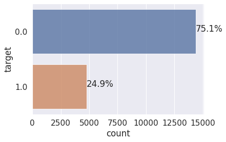

```python
ax = sns.countplot(y="target", data=train_data, alpha=0.8)
total = train_data.shape[0]

for p in ax.patches:
    percent = '{:.1f}%'.format(100*(p.get_width()/total))
    x = p.get_x()+p.get_width()
    y = p.get_y()+(p.get_height())/2
    ax.annotate(percent,(x,y))
```

We can see that this data set is imbalanced Data set since only 25% of people in target data is looking for job change

```python
train_data.describe()
```

|  | enrollee_id | city_development_index | training_hours | target |
| --- | --- | --- | --- | --- |
| count | 19158.000000 | 19158.000000 | 19158.000000 | 19158.000000 |
| mean | 16875.358179 | 0.828848 | 65.366896 | 0.249348 |
| std | 9616.292592 | 0.123362 | 60.058462 | 0.432647 |
| min | 1.000000 | 0.448000 | 1.000000 | 0.000000 |
| 25% | 8554.250000 | 0.740000 | 23.000000 | 0.000000 |
| 50% | 16982.500000 | 0.903000 | 47.000000 | 0.000000 |
| 75% | 25169.750000 | 0.920000 | 88.000000 | 0.000000 |
| max | 33380.000000 | 0.949000 | 336.000000 | 1.000000 |

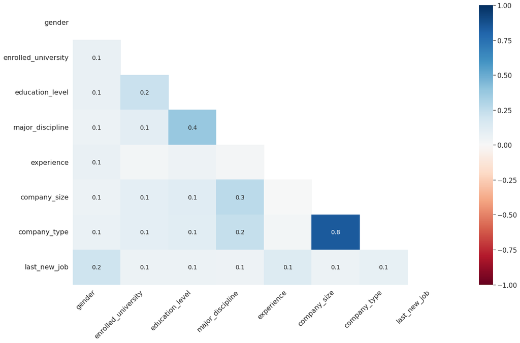

```python
msno.heatmap(train_data)
```

```python
index = train_data.dtypes[train_data.dtypes == object].index
index
```

```
Index(['city', 'gender', 'relevent_experience', 'enrolled_university',
       'education_level', 'major_discipline', 'experience', 'company_size',
       'company_type', 'last_new_job'],
      dtype='object')
```

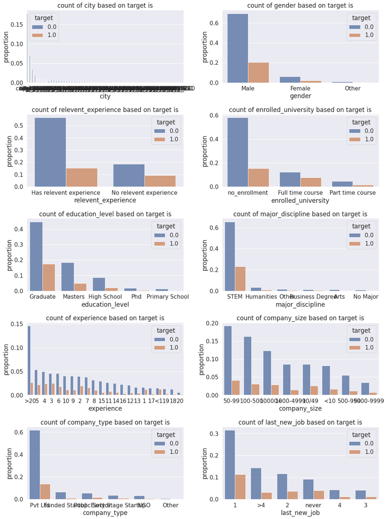

```python
m= 1
plt.figure(figsize=[15,20])
y, hue = "proportion", "target"
for i in index:
    plt.subplot(5,2,m)
    ### we can normalise the data and plot which would make the plot to run faster, and give a clear analysis
    train_data[[i,'target']].value_counts(normalize= True).rename('proportion').reset_index().pipe((sns.barplot,'data'),x=i,y = 'proportion', hue= 'target', alpha =.8)
    m = m+1
    plt.tight_layout()
    #plt.xticks(rotation=45)
    plt.title('count of {} based on target is'.format(i))
```

on second graph Male propotion is higher and most of them are not looking for job change,it doesn't give any information.

on third graph People who have relevent experience are not looking for job change.

on fourth graph we can see people who invlved in full time courses are more likely looking for job change.

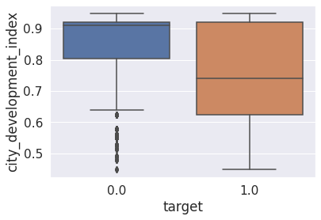

```python
sns.boxplot(x='target',y='city_development_index',data=train_data)
xlabel='target'
ylabel = 'city_development_index'
```

we can see that most of the people liveing in city having index more than 9 are not looking for the job change

Similarly most of the people living in city having low index are looking for job change

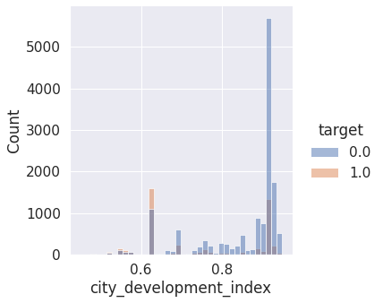

```python
sns.displot(x ='city_development_index',hue='target',data =train_data)
```

we can see that most of the people live in th city index near 0.9 doesn't look for the job change but the people living in city index near .6 more likely looking for job change

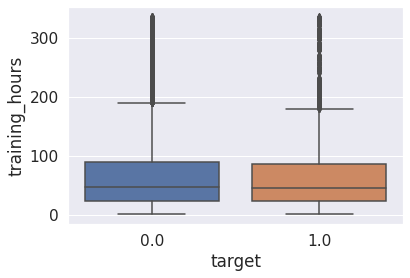

```python
sns.boxplot(y = 'training_hours',x = 'target',data=train_data)
```

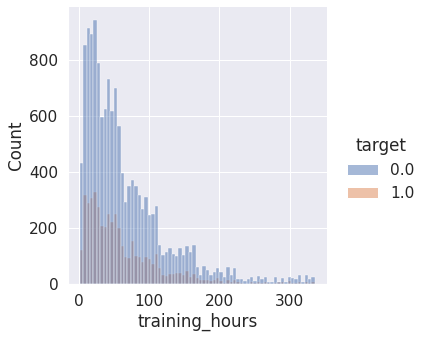

```python
sns.displot(x='training_hours',hue= 'target',data =train_data)
```

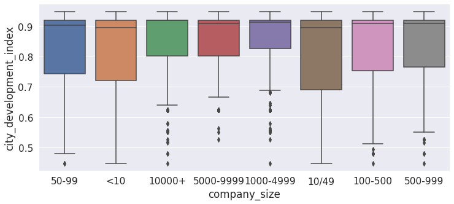

```python
plt.figure(figsize=(12,5))
sns.boxplot(x='company_size',y='city_development_index',data=train_data)
```

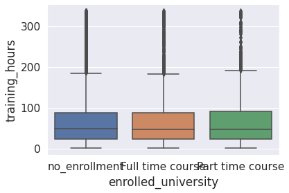

```python
sns.boxplot(x='enrolled_university',y='training_hours',data=train_data)
```

## Data Preprocessing

```python
train_data
```

|  | enrollee_id | city | city_development_index | gender | relevent_experience | enrolled_university | education_level | major_discipline | experience | company_size | company_type | last_new_job | training_hours | target |
| --- | --- | --- | --- | --- | --- | --- | --- | --- | --- | --- | --- | --- | --- | --- |
| 0 | 8949 | city_103 | 0.920 | Male | Has relevent experience | no_enrollment | Graduate | STEM | >20 | NaN | NaN | 1 | 36 | 1.0 |
| 1 | 29725 | city_40 | 0.776 | Male | No relevent experience | no_enrollment | Graduate | STEM | 15 | 50-99 | Pvt Ltd | >4 | 47 | 0.0 |
| 2 | 11561 | city_21 | 0.624 | NaN | No relevent experience | Full time course | Graduate | STEM | 5 | NaN | NaN | never | 83 | 0.0 |
| 3 | 33241 | city_115 | 0.789 | NaN | No relevent experience | NaN | Graduate | Business Degree | <1 | NaN | Pvt Ltd | never | 52 | 1.0 |
| 4 | 666 | city_162 | 0.767 | Male | Has relevent experience | no_enrollment | Masters | STEM | >20 | 50-99 | Funded Startup | 4 | 8 | 0.0 |
| ... | ... | ... | ... | ... | ... | ... | ... | ... | ... | ... | ... | ... | ... | ... |
| 19153 | 7386 | city_173 | 0.878 | Male | No relevent experience | no_enrollment | Graduate | Humanities | 14 | NaN | NaN | 1 | 42 | 1.0 |
| 19154 | 31398 | city_103 | 0.920 | Male | Has relevent experience | no_enrollment | Graduate | STEM | 14 | NaN | NaN | 4 | 52 | 1.0 |
| 19155 | 24576 | city_103 | 0.920 | Male | Has relevent experience | no_enrollment | Graduate | STEM | >20 | 50-99 | Pvt Ltd | 4 | 44 | 0.0 |
| 19156 | 5756 | city_65 | 0.802 | Male | Has relevent experience | no_enrollment | High School | NaN | <1 | 500-999 | Pvt Ltd | 2 | 97 | 0.0 |
| 19157 | 23834 | city_67 | 0.855 | NaN | No relevent experience | no_enrollment | Primary School | NaN | 2 | NaN | NaN | 1 | 127 | 0.0 |

19158 rows × 14 columns

```python
train_data['last_new_job']=train_data['last_new_job'].fillna('DNM')
train_data.head()
```

|  | enrollee_id | city | city_development_index | gender | relevent_experience | enrolled_university | education_level | major_discipline | experience | company_size | company_type | last_new_job | training_hours | target |
| --- | --- | --- | --- | --- | --- | --- | --- | --- | --- | --- | --- | --- | --- | --- |
| 0 | 8949 | city_103 | 0.920 | Male | Has relevent experience | no_enrollment | Graduate | STEM | >20 | NaN | NaN | 1 | 36 | 1.0 |
| 1 | 29725 | city_40 | 0.776 | Male | No relevent experience | no_enrollment | Graduate | STEM | 15 | 50-99 | Pvt Ltd | >4 | 47 | 0.0 |
| 2 | 11561 | city_21 | 0.624 | NaN | No relevent experience | Full time course | Graduate | STEM | 5 | NaN | NaN | never | 83 | 0.0 |
| 3 | 33241 | city_115 | 0.789 | NaN | No relevent experience | NaN | Graduate | Business Degree | <1 | NaN | Pvt Ltd | never | 52 | 1.0 |
| 4 | 666 | city_162 | 0.767 | Male | Has relevent experience | no_enrollment | Masters | STEM | >20 | 50-99 | Funded Startup | 4 | 8 | 0.0 |

```python
def transform(df):

    df['gender']=df['gender'].fillna('DNM')
    df['enrolled_university']=df['enrolled_university'].fillna('DNM')
    df['education_level']=df['education_level'].fillna('DNM')
    df['major_discipline']=df['major_discipline'].fillna('DNM')
    df['Exp'] = np.where(df['experience'].isin(['<1','1','2','3']), "Entry-level Exp", "DNM")
    df['Exp'] = np.where(df['experience'].isin(['4','5','6','7','8']), "Mid-level Exp",df['Exp'])
    df['Exp'] = np.where(df['experience'].isin(['9','10','11','12','13','14','15','16','17','18','19','20','>20']), "Senior-level Exp",df['Exp'])


    df['size'] = np.where(df['company_size'].isin(['50-99','10/49','<10']), "Small Enterprise", "DNM")
    df['size'] = np.where(df['company_size'].isin(['100-500','500-999']), "Medium Enterprise",df['size'])
    df['size'] = np.where(df['company_size'].isin(['10000+','1000-4999','5000-9999']), "Large Enterprise",df['size'])


    df['company_type']=df['company_type'].fillna('DNM')

    df['last_new_job']=df['last_new_job'].fillna('DNM')
    return df

test_data = transform(test_data)
train_data = transform(train_data)
```

```python
train_data
```

|  | enrollee_id | city | city_development_index | gender | relevent_experience | enrolled_university | education_level | major_discipline | experience | company_size | company_type | last_new_job | training_hours | target | Exp | size |
| --- | --- | --- | --- | --- | --- | --- | --- | --- | --- | --- | --- | --- | --- | --- | --- | --- |
| 0 | 8949 | city_103 | 0.920 | Male | Has relevent experience | no_enrollment | Graduate | STEM | >20 | NaN | DNM | 1 | 36 | 1.0 | Senior-level Exp | DNM |
| 1 | 29725 | city_40 | 0.776 | Male | No relevent experience | no_enrollment | Graduate | STEM | 15 | 50-99 | Pvt Ltd | >4 | 47 | 0.0 | Senior-level Exp | Small Enterprise |
| 2 | 11561 | city_21 | 0.624 | DNM | No relevent experience | Full time course | Graduate | STEM | 5 | NaN | DNM | never | 83 | 0.0 | Mid-level Exp | DNM |
| 3 | 33241 | city_115 | 0.789 | DNM | No relevent experience | DNM | Graduate | Business Degree | <1 | NaN | Pvt Ltd | never | 52 | 1.0 | Entry-level Exp | DNM |
| 4 | 666 | city_162 | 0.767 | Male | Has relevent experience | no_enrollment | Masters | STEM | >20 | 50-99 | Funded Startup | 4 | 8 | 0.0 | Senior-level Exp | Small Enterprise |
| ... | ... | ... | ... | ... | ... | ... | ... | ... | ... | ... | ... | ... | ... | ... | ... | ... |
| 19153 | 7386 | city_173 | 0.878 | Male | No relevent experience | no_enrollment | Graduate | Humanities | 14 | NaN | DNM | 1 | 42 | 1.0 | Senior-level Exp | DNM |
| 19154 | 31398 | city_103 | 0.920 | Male | Has relevent experience | no_enrollment | Graduate | STEM | 14 | NaN | DNM | 4 | 52 | 1.0 | Senior-level Exp | DNM |
| 19155 | 24576 | city_103 | 0.920 | Male | Has relevent experience | no_enrollment | Graduate | STEM | >20 | 50-99 | Pvt Ltd | 4 | 44 | 0.0 | Senior-level Exp | Small Enterprise |
| 19156 | 5756 | city_65 | 0.802 | Male | Has relevent experience | no_enrollment | High School | DNM | <1 | 500-999 | Pvt Ltd | 2 | 97 | 0.0 | Entry-level Exp | Medium Enterprise |
| 19157 | 23834 | city_67 | 0.855 | DNM | No relevent experience | no_enrollment | Primary School | DNM | 2 | NaN | DNM | 1 | 127 | 0.0 | Entry-level Exp | DNM |

19158 rows × 16 columns

```python
def transform_data(df):
    df.head()
    df['gender']=df['gender'].replace({'Male':0,'Female':1,'Other':3,'DNM':2})
    df['enrolled_university']=df['enrolled_university'].replace({'no_enrollment':0,'Full time course':1,'Part time course':2, 'DNM':3})
    df['relevent_experience']=df['relevent_experience'].replace({'No relevent experience':0,'Has relevent experience':1})
    df['education_level'] = df['education_level'].replace({'Graduate':1,'High School':4,'Primary School':5,'Masters':2,'Phd':3, 'DNM':6})
    df['major_discipline']=df['major_discipline'].replace({'STEM':1, 'Humanities':2, 'Arts':3, 'Business Degree':4,'No Major':5,'Other':6, 'DNM':7})
    df['Exp'] = df['Exp'].replace({'Entry-level Exp':1, 'Mid-level Exp':2,'Senior-level Exp':3, 'DNM':4 })
    df['size'] = df['size'].replace({'Small Enterprise':1,'Medium Enterprise':2,'Large Enterprise':3, 'DNM':4})
    df['last_new_job']=df['last_new_job'].replace({'>4':5,'1':1,'never':0,'4':4, '3':3, '2':2 ,'DNM':0})
    df['company_type']=df['company_type'].replace({'Pvt Ltd':1,'Funded Startup':2,'Public Sector':3,'Early Stage Startup':4,'NGO':5,'Other':6,'DNM':7})
    return df


train_data=transform_data(train_data)

test_data = transform_data(test_data)
```

```python
train_data.drop(['experience','company_size','enrollee_id','city'],axis =1,inplace = True)
test_data2 = test_data.drop(['experience','company_size' ,'city'],axis =1,inplace = True)
```

```python
y=train_data['target']
x=train_data.drop(['target'],axis=1)
```

## Machine Leaning Models

```python
X_train, X_test, y_train, y_test = train_test_split(x, y, test_size=0.25, random_state=44, shuffle =True)

#Splitted Data
print('X_train shape is ' , X_train.shape)
print('X_test shape is ' , X_test.shape)
print('y_train shape is ' , y_train.shape)
print('y_test shape is ' , y_test.shape)
```

```
X_train shape is  (14368, 11)
X_test shape is  (4790, 11)
y_train shape is  (14368,)
y_test shape is  (4790,)
```

Gradient Boosting Classifier

```python
GBCModel = GradientBoostingClassifier(n_estimators=500,max_depth=50,random_state=33)
GBCModel.fit(X_train, y_train)

#Calculating Details
print('GBCModel Train Score is : ' , GBCModel.score(X_train, y_train))
print('GBCModel Test Score is : ' , GBCModel.score(X_test, y_test))

#Calculating Prediction
y_pred_GCB = GBCModel.predict(X_test)
```

```
GBCModel Train Score is :  0.9959632516703786
GBCModel Test Score is :  0.7417536534446764
```

```python
y_pred = GBCModel.predict(X_test)
acc = accuracy_score(y_test, y_pred)*100
prec = precision_score(y_test, y_pred)
rec = recall_score(y_test, y_pred)
f1 = f1_score(y_test, y_pred)

model_results = pd.DataFrame([['Gradient Boosting Classifier', acc, prec, rec, f1]],
               columns = ['Model', 'Accuracy', 'Precision', 'Recall', 'F1 Score'])

model_results
```

|  | Model | Accuracy | Precision | Recall | F1 Score |
| --- | --- | --- | --- | --- | --- |
| 0 | Gradient Boosting Classifier | 74.175365 | 0.456889 | 0.450877 | 0.453863 |

Decision Tree Classifier

```python
dtc_gini = DecisionTreeClassifier(random_state=42, criterion='gini')
```

```python
# applying  random forest on 'Gini' criterion
dtc_gini.fit(X_train, y_train)

#Calculating Details
print('Decision Tree Classifier Train Score is : ' ,dtc_gini.score(X_train, y_train))
print('Decision Tree Classifier Test Score is : ' , dtc_gini.score(X_test, y_test))

#Calculating Prediction
y_pred_rfc_gini = dtc_gini.predict(X_test)
print('Predicted Value for Decision Tree Classifier is : ' , y_pred_rfc_gini[:10])
print('Prediction Probabilities Value for Decision Tree Classifier is : ' , y_pred_prob[:10])
```

[output not shown]

```python
y_pred = dtc_gini.predict(X_test)
acc = accuracy_score(y_test, y_pred)*100
prec = precision_score(y_test, y_pred)
rec = recall_score(y_test, y_pred)
f1 = f1_score(y_test, y_pred)

model_results = pd.DataFrame([['Decision Tree (Gini)', acc, prec, rec, f1]],
               columns = ['Model', 'Accuracy', 'Precision', 'Recall', 'F1 Score'])

model_results
```

|  | Model | Accuracy | Precision | Recall | F1 Score |
| --- | --- | --- | --- | --- | --- |
| 0 | Decision Tree (Gini) | 72.56785 | 0.42461 | 0.429825 | 0.427201 |

Random Forest Classifier Gini

```python
# applying  random forest on 'Gini' criterion
rfc_gini = RandomForestClassifier(criterion = 'gini',n_estimators=500,max_depth=10,random_state=33)
rfc_gini.fit(X_train, y_train)

#Calculating Details
print('RandomForestClassifierModel Train Score is : ' , rfc_gini.score(X_train, y_train))
print('RandomForestClassifierModel Test Score is : ' , rfc_gini.score(X_test, y_test))

#Calculating Prediction
y_pred_rfc_gini = rfc_gini.predict(X_test)

print('Predicted Value for RandomForestClassifierModel is : ' , y_pred_rfc_gini[:10])
```

```
RandomForestClassifierModel Train Score is :  0.847369153674833
RandomForestClassifierModel Test Score is :  0.8064718162839248
Predicted Value for RandomForestClassifierModel is :  [1. 1. 0. 0. 0. 1. 1. 0. 0. 0.]
```

```python
y_pred = rfc_gini.predict(X_test)
acc = accuracy_score(y_test, y_pred)*100
prec = precision_score(y_test, y_pred)
rec = recall_score(y_test, y_pred)
f1 = f1_score(y_test, y_pred)

model_results = pd.DataFrame([['Random Forest (n=500, Gini)', acc, prec, rec, f1]],
               columns = ['Model', 'Accuracy', 'Precision', 'Recall', 'F1 Score'])

model_results
```

|  | Model | Accuracy | Precision | Recall | F1 Score |
| --- | --- | --- | --- | --- | --- |
| 0 | Random Forest (n=500, Gini) | 80.647182 | 0.598703 | 0.566667 | 0.582244 |

Random Forest Classifier Entropy

```python
rfc_entropy = RandomForestClassifier(criterion = 'entropy',n_estimators=500,max_depth=10,random_state=33) #criterion can be also : entropy
rfc_entropy.fit(X_train, y_train)

#Calculating Details
print('RandomForestClassifierModel Train Score is : ' , rfc_entropy.score(X_train, y_train))
print('RandomForestClassifierModel Test Score is : ' , rfc_entropy.score(X_test, y_test))


#Calculating Prediction
y_pred_rfc_entropy = rfc_entropy.predict(X_test)
y_pred_prob = rfc_entropy.predict_proba(X_test)
print('Predicted Value for RandomForestClassifierModel is : ' , y_pred_rfc_entropy[:10])
```

```
RandomForestClassifierModel Train Score is :  0.8422884187082406
RandomForestClassifierModel Test Score is :  0.8091858037578288
Predicted Value for RandomForestClassifierModel is :  [1. 1. 0. 0. 0. 1. 1. 0. 0. 0.]
```

```python
y_pred = rfc_entropy.predict(X_test)
acc = accuracy_score(y_test, y_pred)*100
prec = precision_score(y_test, y_pred)
rec = recall_score(y_test, y_pred)
f1 = f1_score(y_test, y_pred)

model_results = pd.DataFrame([['Random Forest (n=500, Entropy)', acc, prec, rec, f1]],
               columns = ['Model', 'Accuracy', 'Precision', 'Recall', 'F1 Score'])

model_results
```

|  | Model | Accuracy | Precision | Recall | F1 Score |
| --- | --- | --- | --- | --- | --- |
| 0 | Random Forest (n=500, Entropy) | 80.91858 | 0.602541 | 0.582456 | 0.592328 |

KNeighbour Classifier

```python
classifier = KNeighborsClassifier(n_neighbors=5)
classifier.fit(X_train, y_train)
```

```
KNeighborsClassifier()
```

```python
#Calculating Details
print('KNN Train Score is : ' , classifier.score(X_train, y_train))
print('KNN Test Score is : ' , classifier.score(X_test, y_test))

#Calculating Prediction
y_pred_knn = classifier.predict(X_test)
print('Predicted Value for KNN is : ' , y_pred_knn[:10])
```

```
KNN Train Score is :  0.8032433184855234
KNN Test Score is :  0.7423799582463465
Predicted Value for KNN is :  [0. 1. 0. 0. 0. 0. 0. 0. 0. 0.]
```

```python
y_pred = classifier.predict(X_test)
acc = accuracy_score(y_test, y_pred)*100
prec = precision_score(y_test, y_pred)
rec = recall_score(y_test, y_pred)
f1 = f1_score(y_test, y_pred)

model_results = pd.DataFrame([['Random Forest (n=500, Entropy)', acc, prec, rec, f1]],
               columns = ['Model', 'Accuracy', 'Precision', 'Recall', 'F1 Score'])

model_results
```

[output not shown]

```python
pred = rfc_entropy.predict(test_data.drop('enrollee_id', axis='columns'))
submission = pd.DataFrame({'enrollee_id':test_data['enrollee_id'],'target':pred})
display(submission)
```

|  | enrollee_id | target |
| --- | --- | --- |
| 0 | 32403 | 0.0 |
| 1 | 9858 | 0.0 |
| 2 | 31806 | 0.0 |
| 3 | 27385 | 0.0 |
| 4 | 27724 | 0.0 |
| ... | ... | ... |
| 2124 | 1289 | 0.0 |
| 2125 | 195 | 0.0 |
| 2126 | 31762 | 0.0 |
| 2127 | 7873 | 0.0 |
| 2128 | 12215 | 0.0 |

2129 rows × 2 columns

```python
submission['target'].value_counts()
```

```
0.0    1613
1.0     516
Name: target, dtype: int64
```

```
AUC RandomForestClassifier(criterion='entropy', max_depth=10, n_estimators=500,
                       random_state=33): 0.817
AUC RandomForestClassifier(max_depth=10, n_estimators=500, random_state=33): 0.814
AUC DecisionTreeClassifier(random_state=42): 0.627
AUC GradientBoostingClassifier(max_depth=50, n_estimators=500, random_state=33): 0.740
AUC KNeighborsClassifier(): 0.661
```

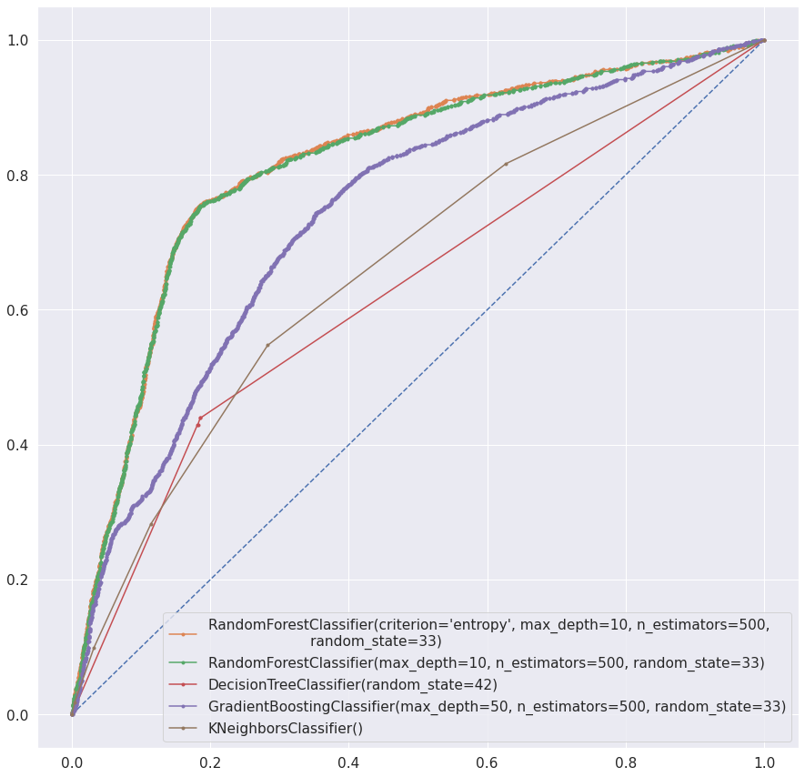

```python
plt.figure(figsize=(15,15))
plt.plot([0, 1], [0, 1], linestyle='--')
for model in [RandomForestClassifier(criterion = 'entropy',n_estimators=500,max_depth=10,random_state=33), RandomForestClassifier(criterion = 'gini',n_estimators=500,max_depth=10,random_state=33),
              DecisionTreeClassifier(random_state=42, criterion='gini') ,GradientBoostingClassifier(n_estimators=500,max_depth=50,random_state=33),KNeighborsClassifier(n_neighbors=5)]:
    model.fit(X_train,y_train)
    probs = model.predict_proba(X_test)
    probs = probs[:, 1]
    auc = roc_auc_score(y_test, probs)
    print(f'AUC {model}: %.3f' % auc)
    fpr, tpr, thresholds = roc_curve(y_test, probs)
    plt.plot(fpr, tpr, marker='.',label=f'{model}')
plt.legend()
#plt.grid()
plt.show()
```

```
Test Data Accuracy: 0.7424
```

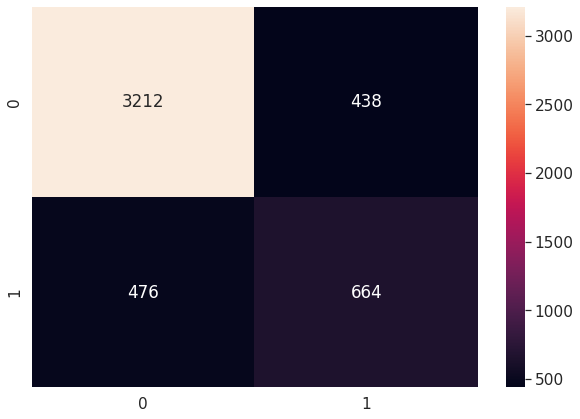

```python
## EXTRA: Confusion Matrix
cm = confusion_matrix(y_test, y_pred_rfc_entropy) # rows = truth, cols = prediction
df_cm = pd.DataFrame(cm, index = (0, 1), columns = (0, 1))
plt.figure(figsize = (10,7))
sns.set(font_scale=1.4)
sns.heatmap(df_cm, annot=True, fmt='g')
print("Test Data Accuracy: %0.4f" % accuracy_score(y_test, y_pred))
```